# Uso de la API del Covid19 con Pandas

API es la abreviatura para "Application Programming Interfaces" (su traducción al español sería interfaz de programación de aplicaciones). Se trata de un conjunto de definiciones y protocolos que se emplea para desarrollar e integrar el software de las aplicaciones. Esto nos permite la comunicación entre dos aplicaciones de software por medio de un conjunto de reglas.

Pandas por su parte es la libería de Python especializada en el manejo y análisis de estructuras de datos. Esta librería dispone de tres estructuras de datos diferentes:

- Series: estrucutura de una dimensión.
- DataFrame: Estructura de dos dimensiones (tablas.
- Panel: Estructura de tres dimensiones (cubos).

En el presente trabajo se analizán datos extraídos de Panda sobre el Covid-19

La URL: https://api.covid19api.com/countries

## Instalación de liberías

```python
!pip install pandas
```

Para instalar la libería hemos utilizado la función "!pip". **Importante** cuando se utiliza el símbolo (!) quiere decir que no estamos ejecutando en Python sino bash

## Configuración de Pandas

Usamos la convención de pandas como pd.

```python
import pandas as pd
```

## Crear variable

En este paso vamos a crear la variable asignando la dirección a la url del principio con el fin de obtener los datos requeridos para llevar a cabo la práctica. Las variables se asignan utilizando el símbolo "=" seguido en este caso de la variable entrecomillada porque se trata de una cadena de caracteres (string).

```python
url = 'https://api.covid19api.com/countries'
```

## Crear el Dataframe

```python
df = pd.read_json(url)
```

```python
df
```

|  | Country | Slug | ISO2 |
| --- | --- | --- | --- |
| 0 | Tonga | tonga | TO |
| 1 | Indonesia | indonesia | ID |
| 2 | Nauru | nauru | NR |
| 3 | Sao Tome and Principe | sao-tome-and-principe | ST |
| 4 | Tajikistan | tajikistan | TJ |
| ... | ... | ... | ... |
| 243 | Vanuatu | vanuatu | VU |
| 244 | Zimbabwe | zimbabwe | ZW |
| 245 | India | india | IN |
| 246 | Libya | libya | LY |
| 247 | Rwanda | rwanda | RW |

248 rows × 3 columns

Surge una tabla por la que visualizamos lo datos a través de tres columnas de valores y una de control de Pandas que identifica cada una de las entradas del dataframe

## Exploración de la tabla

Como hay un número muy alto de valores la tabla no nos los muestra todos. Para poder ver el conjunto de ellos que queramos se utilzia la función head que funciona con 'int'y que nos devuelve en número de filas el valor del entero

```python
df.head()
```

|  | Country | Slug | ISO2 |
| --- | --- | --- | --- |
| 0 | Tonga | tonga | TO |
| 1 | Indonesia | indonesia | ID |
| 2 | Nauru | nauru | NR |
| 3 | Sao Tome and Principe | sao-tome-and-principe | ST |
| 4 | Tajikistan | tajikistan | TJ |

Si queremos ver los 6 primeros valores por ejemplo, escribiremos este número entre los paréntesis de la función "df.head()"

```python
df.head(6)
```

|  | Country | Slug | ISO2 |
| --- | --- | --- | --- |
| 0 | Tonga | tonga | TO |
| 1 | Indonesia | indonesia | ID |
| 2 | Nauru | nauru | NR |
| 3 | Sao Tome and Principe | sao-tome-and-principe | ST |
| 4 | Tajikistan | tajikistan | TJ |
| 5 | Dominica | dominica | DM |

Si lo que queremos es conocer los últimos valores de la cola utilizaremos la función "df.tail()"

```python
df.tail(2)
```

|  | Country | Slug | ISO2 |
| --- | --- | --- | --- |
| 246 | Libya | libya | LY |
| 247 | Rwanda | rwanda | RW |

Para conocer la información general sobre las variables que contiene el dataframe utilizamos la función "df.info"

```python
df.info()
```

```
<class 'pandas.core.frame.DataFrame'>
RangeIndex: 248 entries, 0 to 247
Data columns (total 3 columns):
 #   Column   Non-Null Count  Dtype
---  ------   --------------  -----
 0   Country  248 non-null    object
 1   Slug     248 non-null    object
 2   ISO2     248 non-null    object
dtypes: object(3)
memory usage: 5.9+ KB
```

```python
df['Country']
```

```
0                      Tonga
1                  Indonesia
2                      Nauru
3      Sao Tome and Principe
4                 Tajikistan
               ...
243                  Vanuatu
244                 Zimbabwe
245                    India
246                    Libya
247                   Rwanda
Name: Country, Length: 248, dtype: object
```

Para ver el valor concreto de una columna determinada ponenemos entre corchetes el valor de 'Country' (no entre paréntesis porque no estamos es una lista, si usáranos comillas accederíamos al Index 66). La diferencia entre corchetes y paréntesis radica en el matiz de los diccionarios que son las llaves.

```python
df['Country'][66]
```

```
'Benin'
```

## Tiempo real

La URL que vamos a utilizar de ahora en adelante nos ofrece datos a tiempo real en España en materia del COVID19: https://api.covid19api.com/country/spain/status/confirmed/live

A continuación ejecutaremis las mismas funciones aprendidas previamente pero aplicadas a una región en concreto. Para ello guardaeremos los datos de la misma forma que lo hicimos antes pero como en este caso se trata únicamente de valores relacioandos con España añadiremos "df_es", la abrebiatura que nos indica que este dataframe es de este país.

```python
url_es = 'https://api.covid19api.com/country/spain/status/confirmed/live'
df_es = pd.read_json(url_es)
df_es
```

|  | Country | CountryCode | Province | City | CityCode | Lat | Lon | Cases | Status | Date |
| --- | --- | --- | --- | --- | --- | --- | --- | --- | --- | --- |
| 0 | Spain | ES |  |  |  | 40.46 | -3.75 | 0 | confirmed | 2020-01-22 00:00:00+00:00 |
| 1 | Spain | ES |  |  |  | 40.46 | -3.75 | 0 | confirmed | 2020-01-23 00:00:00+00:00 |
| 2 | Spain | ES |  |  |  | 40.46 | -3.75 | 0 | confirmed | 2020-01-24 00:00:00+00:00 |
| 3 | Spain | ES |  |  |  | 40.46 | -3.75 | 0 | confirmed | 2020-01-25 00:00:00+00:00 |
| 4 | Spain | ES |  |  |  | 40.46 | -3.75 | 0 | confirmed | 2020-01-26 00:00:00+00:00 |
| ... | ... | ... | ... | ... | ... | ... | ... | ... | ... | ... |
| 821 | Spain | ES |  |  |  | 40.46 | -3.75 | 11786036 | confirmed | 2022-04-22 00:00:00+00:00 |
| 822 | Spain | ES |  |  |  | 40.46 | -3.75 | 11786036 | confirmed | 2022-04-23 00:00:00+00:00 |
| 823 | Spain | ES |  |  |  | 40.46 | -3.75 | 11786036 | confirmed | 2022-04-24 00:00:00+00:00 |
| 824 | Spain | ES |  |  |  | 40.46 | -3.75 | 11786036 | confirmed | 2022-04-25 00:00:00+00:00 |
| 825 | Spain | ES |  |  |  | 40.46 | -3.75 | 11833457 | confirmed | 2022-04-26 00:00:00+00:00 |

826 rows × 10 columns

## Exploración de datos

Cabeceras

```python
df_es.head()
```

|  | Country | CountryCode | Province | City | CityCode | Lat | Lon | Cases | Status | Date |
| --- | --- | --- | --- | --- | --- | --- | --- | --- | --- | --- |
| 0 | Spain | ES |  |  |  | 40.46 | -3.75 | 0 | confirmed | 2020-01-22 00:00:00+00:00 |
| 1 | Spain | ES |  |  |  | 40.46 | -3.75 | 0 | confirmed | 2020-01-23 00:00:00+00:00 |
| 2 | Spain | ES |  |  |  | 40.46 | -3.75 | 0 | confirmed | 2020-01-24 00:00:00+00:00 |
| 3 | Spain | ES |  |  |  | 40.46 | -3.75 | 0 | confirmed | 2020-01-25 00:00:00+00:00 |
| 4 | Spain | ES |  |  |  | 40.46 | -3.75 | 0 | confirmed | 2020-01-26 00:00:00+00:00 |

```python
df_es['Date'].head(1)
```

```
0   2020-01-22 00:00:00+00:00
Name: Date, dtype: datetime64[ns, UTC]
```

Por columnas

```python
df_es.columns
```

```
Index(['Country', 'CountryCode', 'Province', 'City', 'CityCode', 'Lat', 'Lon',
       'Cases', 'Status', 'Date'],
      dtype='object')
```

Cola

```python
df_es['Date'].tail(1)
```

```
825   2022-04-26 00:00:00+00:00
Name: Date, dtype: datetime64[ns, UTC]
```

Información sobre la variable

```python
df_es.info()
```

```
<class 'pandas.core.frame.DataFrame'>
RangeIndex: 826 entries, 0 to 825
Data columns (total 10 columns):
 #   Column       Non-Null Count  Dtype
---  ------       --------------  -----
 0   Country      826 non-null    object
 1   CountryCode  826 non-null    object
 2   Province     826 non-null    object
 3   City         826 non-null    object
 4   CityCode     826 non-null    object
 5   Lat          826 non-null    float64
 6   Lon          826 non-null    float64
 7   Cases        826 non-null    int64
 8   Status       826 non-null    object
 9   Date         826 non-null    datetime64[ns, UTC]
dtypes: datetime64[ns, UTC](1), float64(2), int64(1), object(6)
memory usage: 64.7+ KB
```

```python
df_es.describe()
```

|  | Lat | Lon | Cases |
| --- | --- | --- | --- |
| count | 8.260000e+02 | 826.00 | 8.260000e+02 |
| mean | 4.046000e+01 | -3.75 | 3.477175e+06 |
| std | 1.421946e-14 | 0.00 | 3.365777e+06 |
| min | 4.046000e+01 | -3.75 | 0.000000e+00 |
| 25% | 4.046000e+01 | -3.75 | 3.428130e+05 |
| 50% | 4.046000e+01 | -3.75 | 3.183704e+06 |
| 75% | 4.046000e+01 | -3.75 | 4.961128e+06 |
| max | 4.046000e+01 | -3.75 | 1.183346e+07 |

Últimos valores

```python
df_es['Date'].tail(1)
```

```
825   2022-04-26 00:00:00+00:00
Name: Date, dtype: datetime64[ns, UTC]
```

## Creación de gráficos

Esta es la función que nos llevará a hacer la siguiente tabla donde podremos visualizar los datos. Par ayudarnos a hacer este gráfico sobre los datos escogemos un dato Índice (de ahí la función set index)

```python
df_es.set_index('Date')
```

| Date | Country | CountryCode | Province | City | CityCode | Lat | Lon | Cases | Status |
| --- | --- | --- | --- | --- | --- | --- | --- | --- | --- |
| 2020-01-22 00:00:00+00:00 | Spain | ES |  |  |  | 40.46 | -3.75 | 0 | confirmed |
| 2020-01-23 00:00:00+00:00 | Spain | ES |  |  |  | 40.46 | -3.75 | 0 | confirmed |
| 2020-01-24 00:00:00+00:00 | Spain | ES |  |  |  | 40.46 | -3.75 | 0 | confirmed |
| 2020-01-25 00:00:00+00:00 | Spain | ES |  |  |  | 40.46 | -3.75 | 0 | confirmed |
| 2020-01-26 00:00:00+00:00 | Spain | ES |  |  |  | 40.46 | -3.75 | 0 | confirmed |
| ... | ... | ... | ... | ... | ... | ... | ... | ... | ... |
| 2022-04-22 00:00:00+00:00 | Spain | ES |  |  |  | 40.46 | -3.75 | 11786036 | confirmed |
| 2022-04-23 00:00:00+00:00 | Spain | ES |  |  |  | 40.46 | -3.75 | 11786036 | confirmed |
| 2022-04-24 00:00:00+00:00 | Spain | ES |  |  |  | 40.46 | -3.75 | 11786036 | confirmed |
| 2022-04-25 00:00:00+00:00 | Spain | ES |  |  |  | 40.46 | -3.75 | 11786036 | confirmed |
| 2022-04-26 00:00:00+00:00 | Spain | ES |  |  |  | 40.46 | -3.75 | 11833457 | confirmed |

826 rows × 9 columns

A continuacuón creamos una tabla en la que se incluyan tanto la columna de la "fecha" como también la de "casos confirmados"

```python
df_es.set_index('Date')['Cases']
```

```
Date
2020-01-22 00:00:00+00:00           0
2020-01-23 00:00:00+00:00           0
2020-01-24 00:00:00+00:00           0
2020-01-25 00:00:00+00:00           0
2020-01-26 00:00:00+00:00           0
                               ...
2022-04-22 00:00:00+00:00    11786036
2022-04-23 00:00:00+00:00    11786036
2022-04-24 00:00:00+00:00    11786036
2022-04-25 00:00:00+00:00    11786036
2022-04-26 00:00:00+00:00    11833457
Name: Cases, Length: 826, dtype: int64
```

## Creamos la tabla

Para poder visualizar los datos en su totalidad creamos un gráfico. Pintamos la función por plor, la forma de visualización de datos más sencilla de Python.

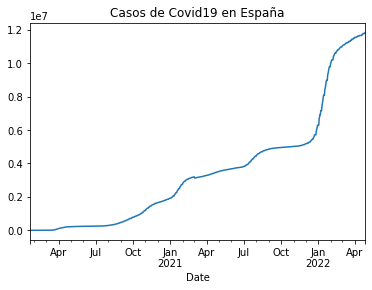

```python
df_es.set_index('Date')['Cases'].plot(title="Casos de Covid19 en España")
```

Al añadirle "title=..." le puedo poner el nombre que yo quiera a la tabla

## Otro país: Italia

En este apartado de la tarea simplemente cambiamos los datos de España a Italia y vemos qué ocurre en cada función

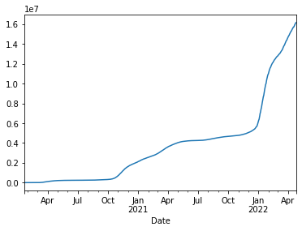

```python
url_it = 'https://api.covid19api.com/country/italy/status/confirmed/live'
df_it = pd.read_json(url_it)
df_it.set_index('Date')['Cases'].plot()
```

## Uruguay

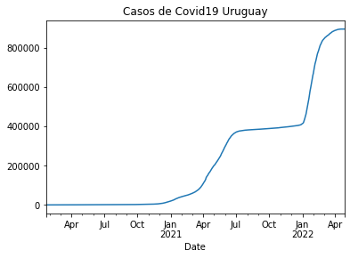

```python
url_ur = 'https://api.covid19api.com/country/uruguay/status/confirmed/live'
df_ur = pd.read_json(url_ur)
df_ur.set_index('Date')['Cases'].plot(title= "Casos de Covid19 Uruguay")
```

## Comparación

Estas vistas creadas las vamos a guardar como objetos para poder agruparlas y compararlas.

```python
casos_es = df_es.set_index('Date')['Cases']
casos_it = df_it.set_index('Date')['Cases']
casos_ur = df_ur.set_index('Date')['Cases']
```

```python
casos_ur
```

```
Date
2020-01-22 00:00:00+00:00         0
2020-01-23 00:00:00+00:00         0
2020-01-24 00:00:00+00:00         0
2020-01-25 00:00:00+00:00         0
2020-01-26 00:00:00+00:00         0
                              ...
2022-04-23 00:00:00+00:00    895775
2022-04-24 00:00:00+00:00    895775
2022-04-25 00:00:00+00:00    895775
2022-04-26 00:00:00+00:00    895775
2022-04-27 00:00:00+00:00    895775
Name: Cases, Length: 827, dtype: int64
```

```python
pd.concat([casos_es,casos_it,casos_ur],axis=1)
```

| Date | Cases | Cases | Cases |
| --- | --- | --- | --- |
| 2020-01-22 00:00:00+00:00 | 0.0 | 0.0 | 0 |
| 2020-01-23 00:00:00+00:00 | 0.0 | 0.0 | 0 |
| 2020-01-24 00:00:00+00:00 | 0.0 | 0.0 | 0 |
| 2020-01-25 00:00:00+00:00 | 0.0 | 0.0 | 0 |
| 2020-01-26 00:00:00+00:00 | 0.0 | 0.0 | 0 |
| ... | ... | ... | ... |
| 2022-04-23 00:00:00+00:00 | 11786036.0 | 16079209.0 | 895775 |
| 2022-04-24 00:00:00+00:00 | 11786036.0 | 16136057.0 | 895775 |
| 2022-04-25 00:00:00+00:00 | 11786036.0 | 16161339.0 | 895775 |
| 2022-04-26 00:00:00+00:00 | 11833457.0 | 16191323.0 | 895775 |
| 2022-04-27 00:00:00+00:00 | NaN | NaN | 895775 |

827 rows × 3 columns

```python
vs = pd.concat([casos_es,casos_it,casos_ur],axis=1)
```

```python
vs
```

| Date | Cases | Cases | Cases |
| --- | --- | --- | --- |
| 2020-01-22 00:00:00+00:00 | 0.0 | 0.0 | 0 |
| 2020-01-23 00:00:00+00:00 | 0.0 | 0.0 | 0 |
| 2020-01-24 00:00:00+00:00 | 0.0 | 0.0 | 0 |
| 2020-01-25 00:00:00+00:00 | 0.0 | 0.0 | 0 |
| 2020-01-26 00:00:00+00:00 | 0.0 | 0.0 | 0 |
| ... | ... | ... | ... |
| 2022-04-23 00:00:00+00:00 | 11786036.0 | 16079209.0 | 895775 |
| 2022-04-24 00:00:00+00:00 | 11786036.0 | 16136057.0 | 895775 |
| 2022-04-25 00:00:00+00:00 | 11786036.0 | 16161339.0 | 895775 |
| 2022-04-26 00:00:00+00:00 | 11833457.0 | 16191323.0 | 895775 |
| 2022-04-27 00:00:00+00:00 | NaN | NaN | 895775 |

827 rows × 3 columns

Para crear el gráfico vamos a nombrar las variables: los casos de cada país con el correspondiente nombre de cada uno como leyenda de la gráfica.

```python
vs.columns = ['España', 'Italia', 'Uruguay']
```

```python
vs
```

| Date | España | Italia | Uruguay |
| --- | --- | --- | --- |
| 2020-01-22 00:00:00+00:00 | 0.0 | 0.0 | 0 |
| 2020-01-23 00:00:00+00:00 | 0.0 | 0.0 | 0 |
| 2020-01-24 00:00:00+00:00 | 0.0 | 0.0 | 0 |
| 2020-01-25 00:00:00+00:00 | 0.0 | 0.0 | 0 |
| 2020-01-26 00:00:00+00:00 | 0.0 | 0.0 | 0 |
| ... | ... | ... | ... |
| 2022-04-23 00:00:00+00:00 | 11786036.0 | 16079209.0 | 895775 |
| 2022-04-24 00:00:00+00:00 | 11786036.0 | 16136057.0 | 895775 |
| 2022-04-25 00:00:00+00:00 | 11786036.0 | 16161339.0 | 895775 |
| 2022-04-26 00:00:00+00:00 | 11833457.0 | 16191323.0 | 895775 |
| 2022-04-27 00:00:00+00:00 | NaN | NaN | 895775 |

827 rows × 3 columns

Siguiendo los mismos pasos que antes, para visualizar el gráfico utilizaremos la función "plot"

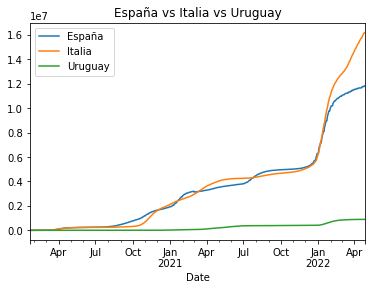

```python
vs.plot(title="España vs Italia vs Uruguay")
```

El gráfico que queremos utilizar para representar nuestros valores es un gráfico de áreas, para lo que utilizaremos el atributo "kind".

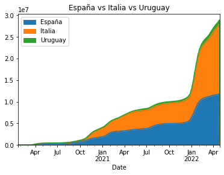

```python
vs.plot(title="España vs Italia vs Uruguay", kind='area')
```

## Guardar el gráfico

Vamos a guardar el gráfico en CVS. De esta forma nuestro dataframe que había sido denominado como "vs" será guardado en nuestro perfil de Jupyter.

```python
vs.to_csv('esvsit.csv')
```

Para saber dónde lo hemos guardado utilizamos el comando de bash "ls"=listado (recordamos que como vamos a trabajar en lenguaje bash tenemos que añadir !):

```python
!ls
```

```
esvsit.csv	      pyhton-primeros-pasos.ipynb    Untitled.ipynb
probando-con-r.ipynb  python-api-covid-pandas.ipynb
Prueba-con-r.ipynb    Shared_Resources
```

## Guardar la imágen

Acabamos de guardar nuestro gráfico y nuestros datos con cvs. Para guardar la gráfica también como imagen utilizamos el comando "matplotlib", una librería que nos permite visualizar los datos en Jupyter y desde ahí mismo guardarlos en png.

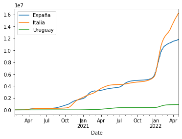

```python
import matplotlib.pyplot as plt
vs.plot()
plt.savefig('esvsitvmx.png')
```

Para comprobar que hemos hecho los pasos correctos y se ha guardado debidamente ejecutamos el comando de listado en bash otra vez.

```python
!ls
```

```
esvsit.csv	      Prueba-con-r.ipynb	     Shared_Resources
esvsitvmx.png	      pyhton-primeros-pasos.ipynb    Untitled.ipynb
probando-con-r.ipynb  python-api-covid-pandas.ipynb
```